# GAM modelling with mgcv

Matteo Fasiolo

June 11 2025

The `mgcv` R package offers tools for building and fitting GAMs, using the methods described in [Wood, 2017](https://www.crcpress.com/Generalized-Additive-Models-An-Introduction-with-R-Second-Edition/Wood/p/book/9781498728331). The main fitting function is `gam()`, which fits an GAM models and returns an object of class `gam`. See `?gamObject`.

# Modelling the GEFCom14 electricity demand data

Load data and have a look at it:

```r
library(testGam)
data("gefcom_small")
head(gefcom_small)   # wM_s95[t] = 0.95 * wM_s95[t-1] + 0.05 * wM[t]
```

```
##   Year NetDemand       wM       Posan        Trend Dow    wM_s95 NetDemand.24
## 1 2005  2.889407 16.38889 0.001370019 0.0000000000   6  8.236849     2.889407
## 2 2005  2.543342 17.36111 0.004110058 0.0003961965   0  9.933947     2.889407
## 3 2005  2.446159 18.88889 0.006850097 0.0007923930   1 10.794862     2.543342
## 4 2005  2.190166 21.25000 0.009590136 0.0011885895   2 14.462260     2.446159
## 5 2005  2.100094 20.83333 0.012330175 0.0015847861   3 16.194613     2.190166
## 6 2005  2.130908 20.83333 0.015070213 0.0019809826   4 16.341327     2.100094
```

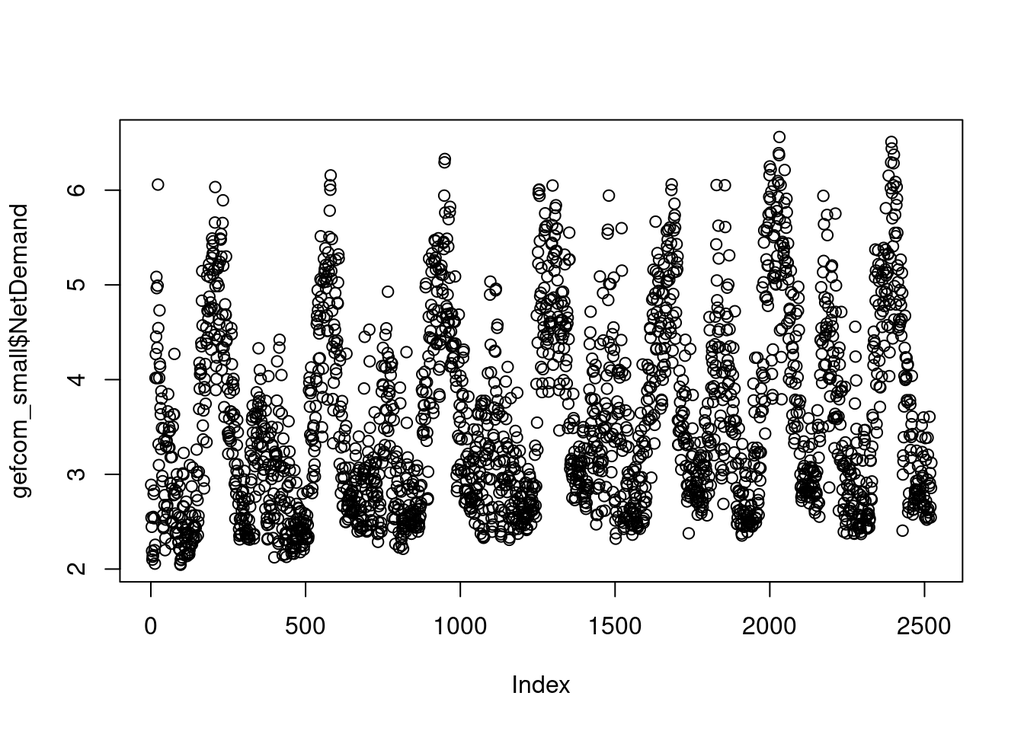

```r
plot(gefcom_small$NetDemand)
```

We divide into a train and a testing data set:

```r
train <- gefcom_small[gefcom_small$Year < 2011, ]
test <- gefcom_small[gefcom_small$Year == 2011, ]
```

Fit a basic Gaussian GAM:

```r
library(mgcv)
fit1 <- gam(formula = NetDemand ~ NetDemand.24 + Dow + Trend +
                      wM + wM_s95 + s(Posan, bs = "cc"),
            data = train)
```

Visualise the seasonal effect:

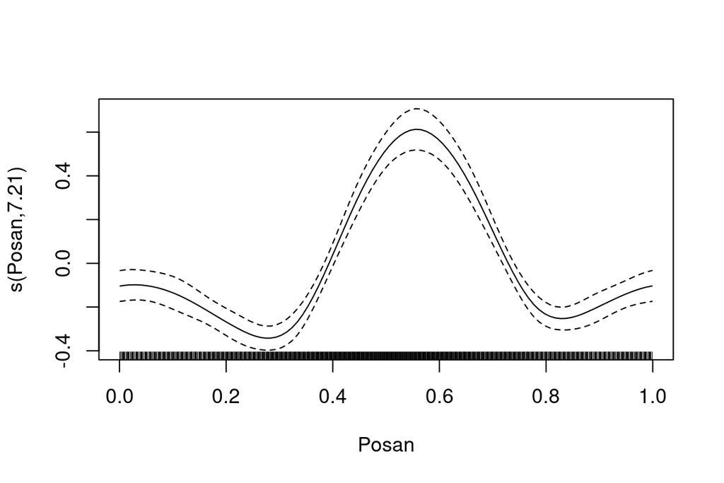

```r
plot(fit1)
```

Visualise all terms:

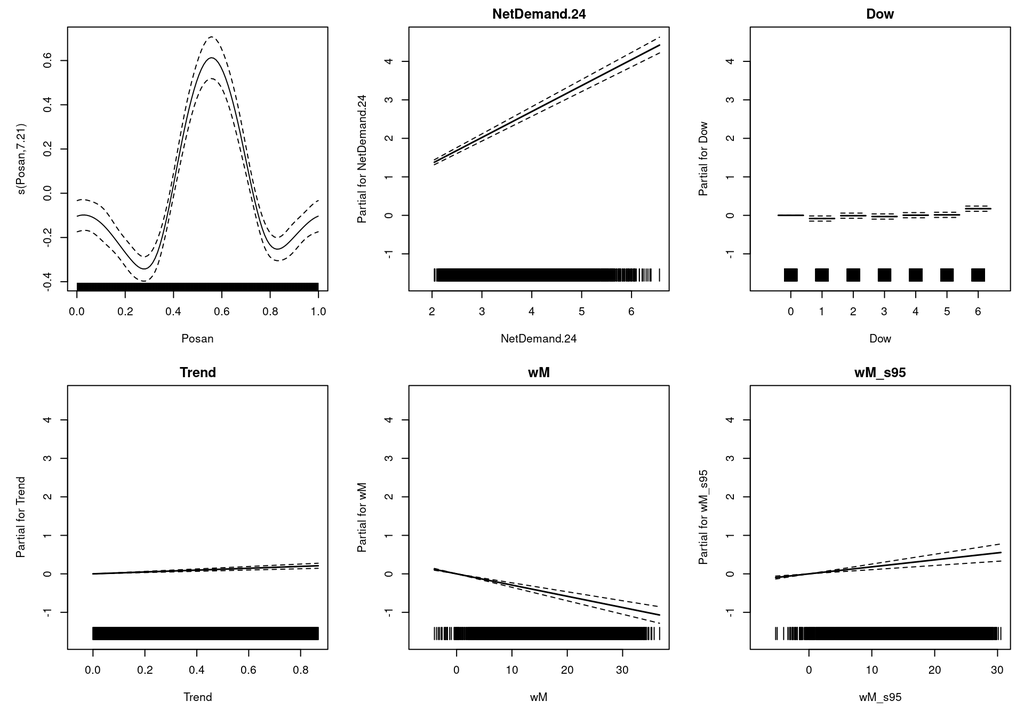

```r
plot(fit1, all.terms = TRUE, pages = 1)
```

We use `pages = 1` to plot on a single page, and `all.terms` to plot also the parametric effects (the plotting method used here plots only smooth or random effects by default).

Should we model temperature effect non-linearly? If the effect of `wM` was non-linear, we would expect that the mean of the residuals would depart from 0, as we move along `wM`. We can use a marginal residual check:

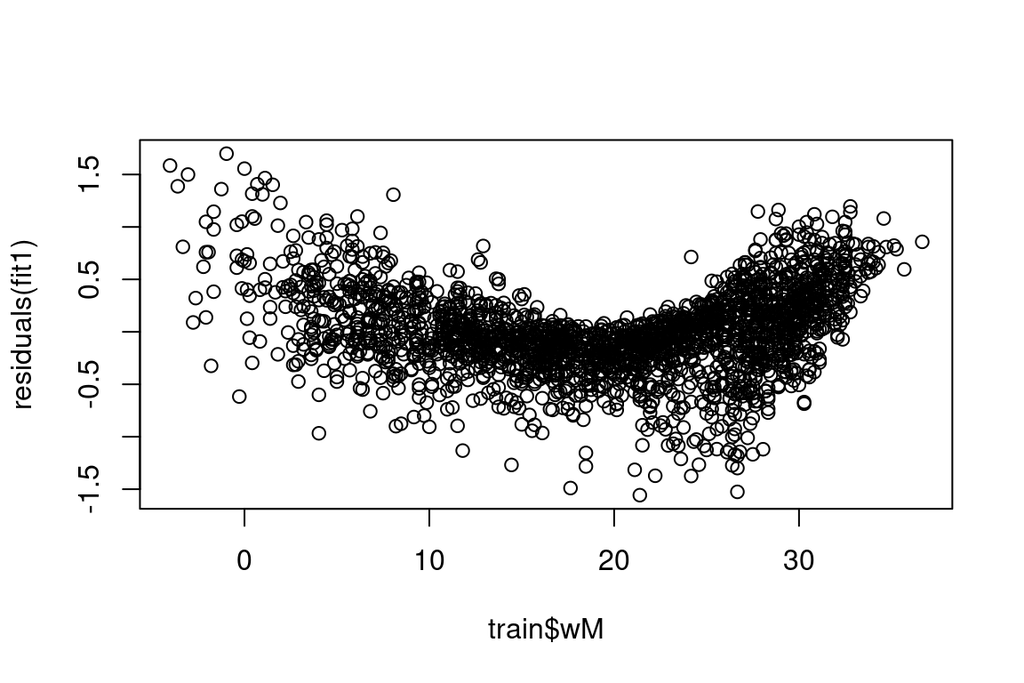

```r
plot(train$wM, residuals(fit1))
```

There is definitely a pattern here. An analogous plot along `wM_s95` also shows a residual pattern, hence we consider the model:

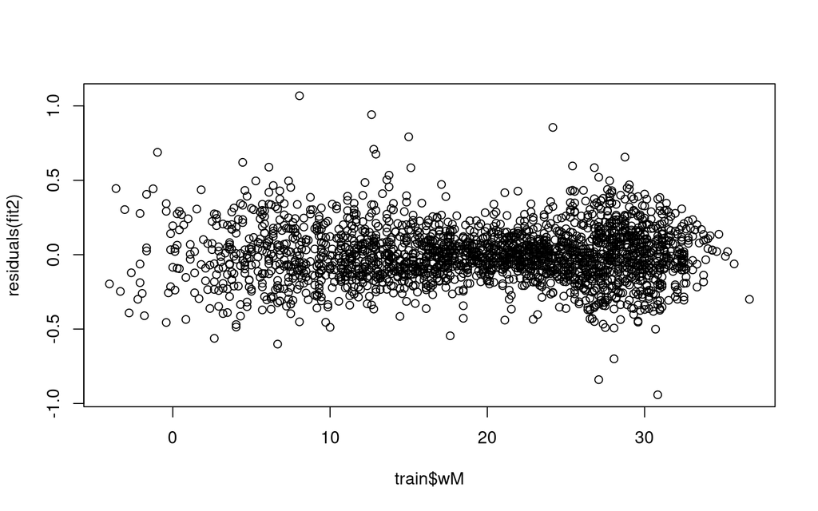

```r
fit2 <- gam(formula = NetDemand ~ NetDemand.24 + Dow + Trend +
                       s(wM) + s(wM_s95) + s(Posan, bs = "cc"),
             data = train)

plot(train$wM, residuals(fit2))
```

Get some diagnostics on the last model:

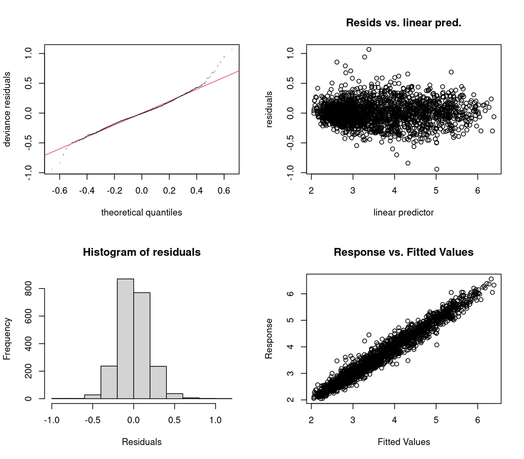

```
##
## Method: GCV   Optimizer: magic
## Smoothing parameter selection converged after 11 iterations.
## The RMS GCV score gradient at convergence was 6.328953e-07 .
## The Hessian was positive definite.
## Model rank =  35 / 35
##
## Basis dimension (k) checking results. Low p-value (k-index<1) may
## indicate that k is too low, especially if edf is close to k'.
##
##             k'  edf k-index p-value
## s(wM)     9.00 8.52    0.94  <2e-16 ***
## s(wM_s95) 9.00 7.84    1.03    0.89
## s(Posan)  8.00 7.64    1.02    0.80
## ---
## Signif. codes:  0 '***' 0.001 '**' 0.01 '*' 0.05 '.' 0.1 ' ' 1
```

```r
gam.check(fit2)
```

We might need more basis functions for `wM`:

```r
fit3 <- gam(formula = NetDemand ~ NetDemand.24 + Dow + Trend +
                       s(wM, k = 15) + s(wM_s95) + s(Posan, bs = "cc"),
             data = train)

AIC(fit1, fit2, fit3)
```

```
##            df       AIC
## fit1 19.20674  2425.180
## fit2 33.99971 -1081.444
## fit3 38.39005 -1085.873
```

Get p-values etc:

```r
summary(fit3)
```

```
##
## Family: gaussian
## Link function: identity
##
## Formula:
## NetDemand ~ NetDemand.24 + Dow + Trend + s(wM, k = 15) + s(wM_s95) +
##     s(Posan, bs = "cc")
##
## Parametric coefficients:
##              Estimate Std. Error t value Pr(>|t|)
## (Intercept)   2.98015    0.04752  62.707  < 2e-16 ***
## NetDemand.24  0.12405    0.01325   9.361  < 2e-16 ***
## Dow1         -0.11977    0.01504  -7.962 2.72e-15 ***
## Dow2         -0.13345    0.01523  -8.762  < 2e-16 ***
## Dow3         -0.13551    0.01528  -8.868  < 2e-16 ***
## Dow4         -0.11411    0.01533  -7.445 1.39e-13 ***
## Dow5         -0.10812    0.01528  -7.075 2.01e-12 ***
## Dow6          0.06689    0.01521   4.398 1.15e-05 ***
## Trend         0.49833    0.01815  27.450  < 2e-16 ***
## ---
## Signif. codes:  0 '***' 0.001 '**' 0.01 '*' 0.05 '.' 0.1 ' ' 1
##
## Approximate significance of smooth terms:
##              edf Ref.df      F p-value
## s(wM)     12.887 13.754 361.41  <2e-16 ***
## s(wM_s95)  7.868  8.689  44.64  <2e-16 ***
## s(Posan)   7.635  8.000  92.03  <2e-16 ***
## ---
## Signif. codes:  0 '***' 0.001 '**' 0.01 '*' 0.05 '.' 0.1 ' ' 1
##
## R-sq.(adj) =  0.964   Deviance explained = 96.5%
## GCV = 0.035639  Scale est. = 0.03503   n = 2190
```

Get QQ-plot of residuals looks fine:

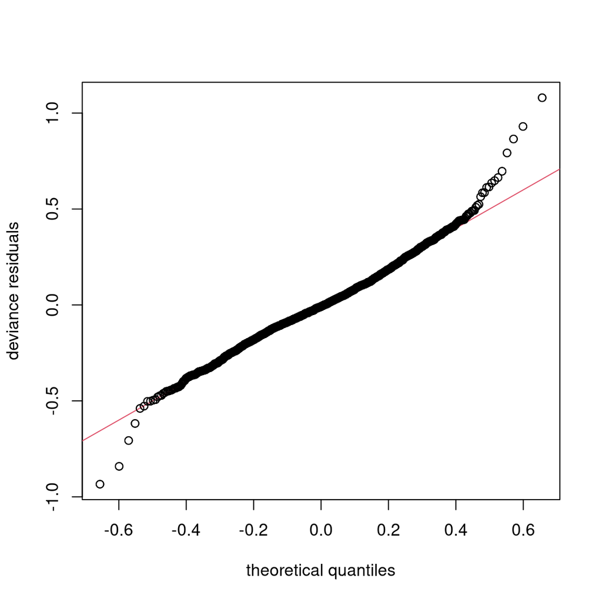

```r
qq.gam(fit3, pch = 1)
```

Making predictions on test set:

```r
preds <- predict(fit3, newdata = test)
head(preds)
```

```
##     2191     2192     2193     2194     2195     2196
## 3.422938 3.000925 4.224980 4.030076 3.886357 4.305225
```

Plot the fit:

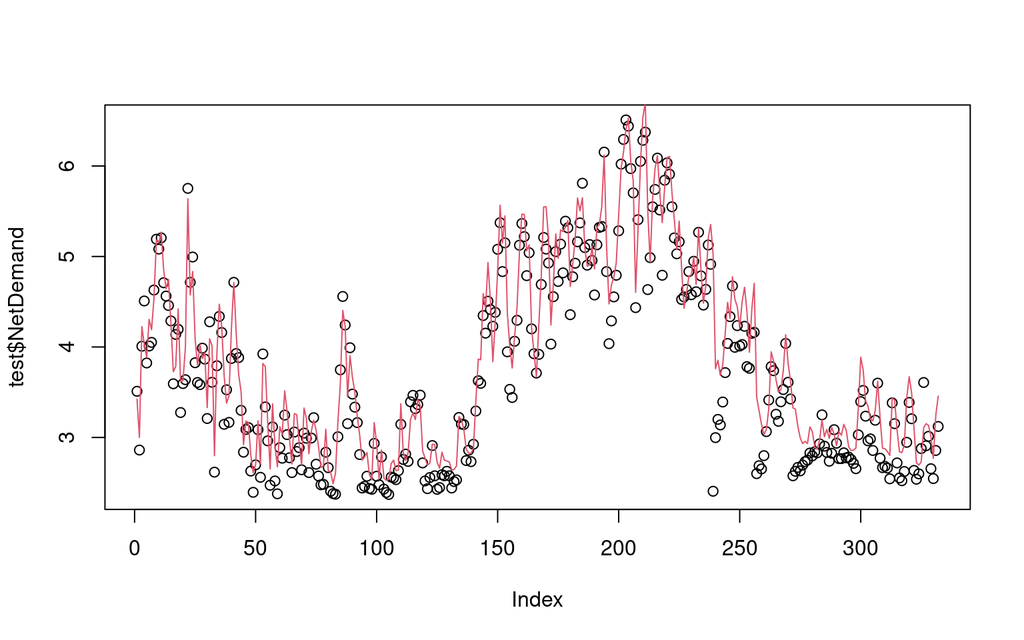

```r
plot(test$NetDemand)
lines(preds, col = 2)
```

# References

Wood S. N. (2017) Generalized additive models: an introduction with R. Second edition. Chapman and Hall/CRC, 2017.